# HW 2: Analysis of the success of projects launched on the Kickstarter platform

Сучкова Ангелина, assuchkova_1

## Задача

На основе данных нужно:

- выяснить, какие факторы определяют успешность проекта
- построить модель, предсказывающую будет ли проект успешен

#### Загрузка данных и преобразование

Необходимые данные (большинство) представлены в пригодном для анализа виде. Дальнейшие преобразования сделаны в ходе исследования по мере необходимости.

### Шаги

#### Шаг 1: Общий анализ и выявления тенденций

**Вопрос 1:** Какие категории проектов наиболее популярны на Kickstarter? В каких категориях большинство проектов успешны?

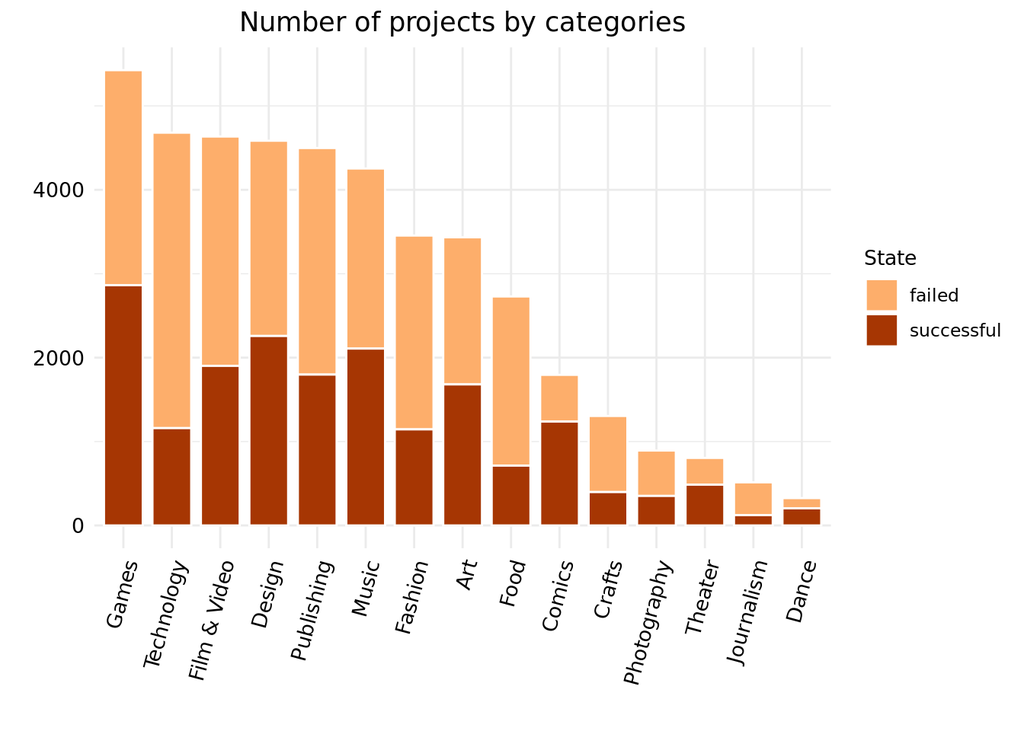

**Ответ:** Cудя по результатам, **наибольшее количество проектов** на платформе относится к категориям Games, Technology, Film & Video, Design, Publishing and Music (>4000). Причем **процентное количество успешных проектов** от общего числа проектов больше в категориях Comics, Dance, Theater, Games and Music (процент успешных проектов 49-69%, значит, можно сказать, что более половины успешных проектов - это показатель того, что категория в целом имеет неплохой потенциал)

**Вопрос 2:** Есть ли выбросы в данных (usd_goal_real), которые могут сильно исказить результаты исследования?

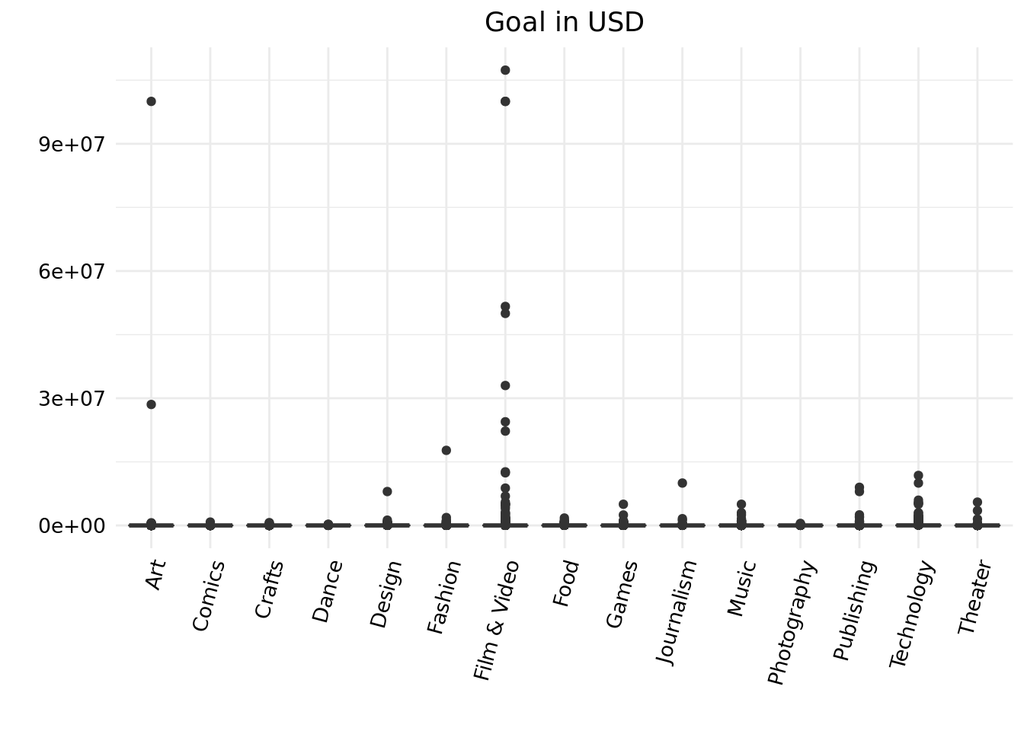

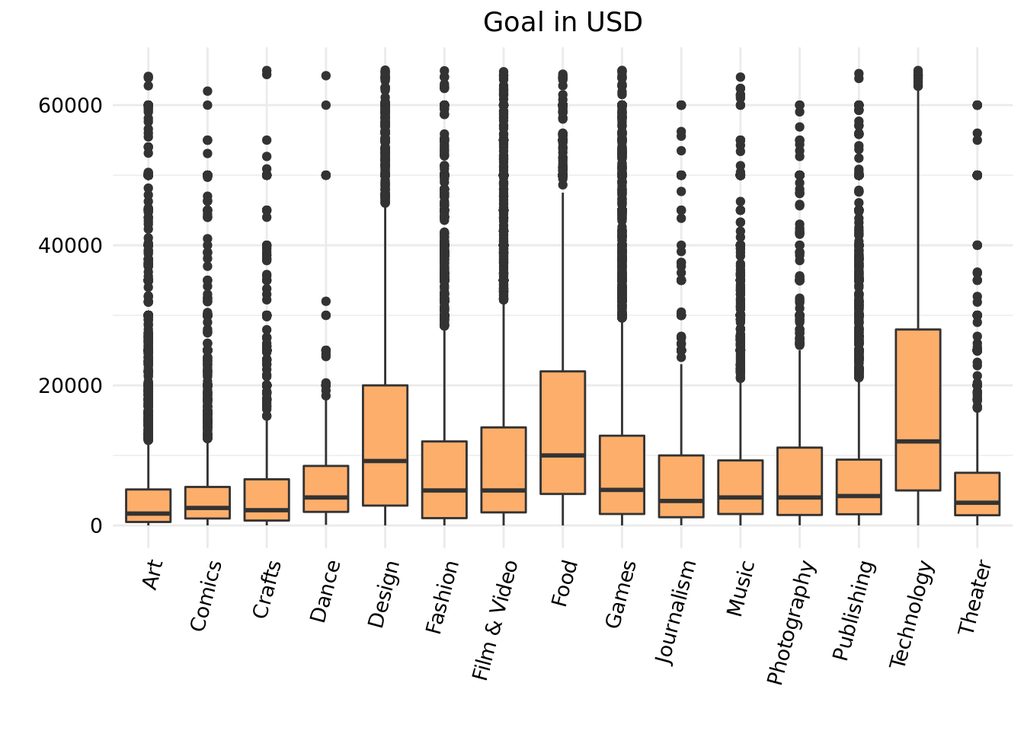

**Ответ:** Как видим, у нас **есть до такой степени “экстремальные” выбросы**, что на исходных данных boxplot не показывает практически никакой информации о данных. После удаления 0.05 процентов верхних значений, график по-прежнему показывает большое количество выбросов, но они уже не так сильно искажают результаты, как удаленные нами выбросы.

**Вопрос 3:** Насколько отличается среднее значение usd_goal_real по категориям проектов? (будем работать с данными без выбросов)

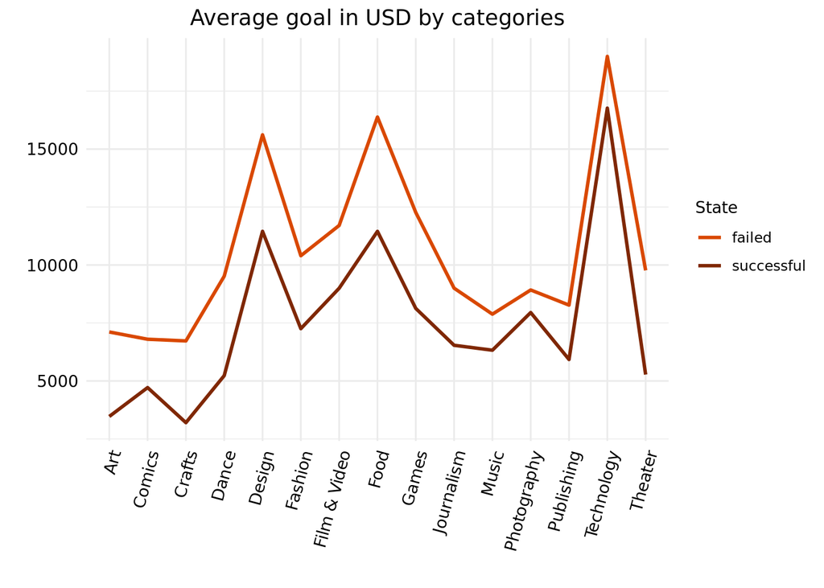

**Ответ:** Таким образом, мы видим, что **среднее значение цели ниже для проектов, которые оказались успешными,** из всех категорий. Разница между размером цели для успешных и провальных проекта в среднем составляет 3-5 тыс. долларов. Самые высокие значения цели представлены в категориях Design, Food и Technology.

**Вопрос 4:** Если ли наглядная зависимость между размером цели и продолжительностью сбора средств(period)?

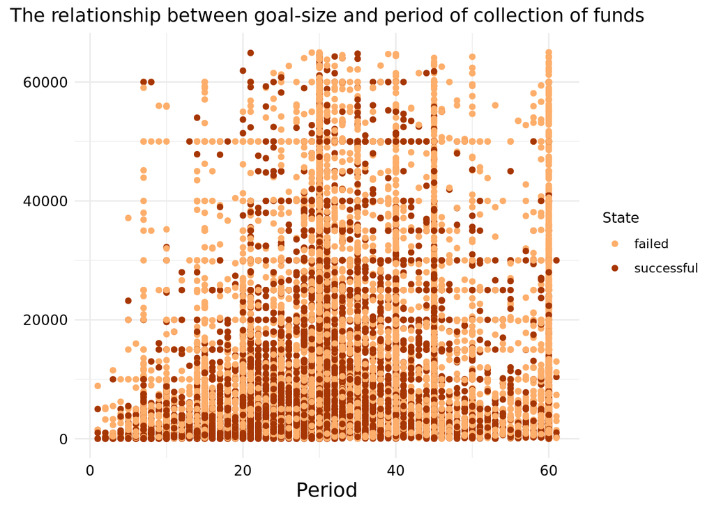

**Ответ:**По графику видно, что прямой зависимости между данными нет. Можно только препдоложить, что наиболее популярные периоды для сбора средств это **месяц, полтора месяца и два месяца.**

**Вопрос 5:** На сколько отличается количество спонсоров (backers) для разных категорий проектов?

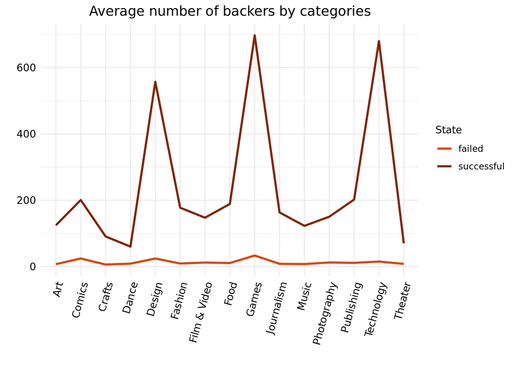

#### Шаг 2: Построение предсказательной модели и ее оценка

**1.** Разделим выборку на обучающую и тестовую и попробуем построить дерево, чтобы определить значимые для нас переменные.

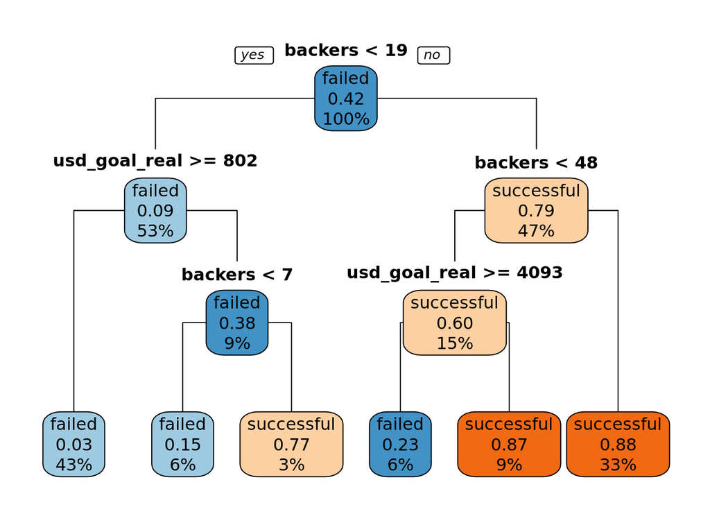

**Видим, что значимые для нашей модели переменные - это backers и usd_goal_real**. На основе дерева можно сформировать правила, следуя которым, можно будет предсказать успешность проекта.

**2.** Проверим точность модели на тренировочной и тестовой выборке.

**Accuracy values of our model for two samples**

| Indicator | Value |
| --- | --- |
| Accuracy (train) | 0.9058209 |
| Accuracy (test) | 0.9041191 |

**Точность модели на разных выборках практически одинакова и равна 90 %,**что говорит о высоком качестве модели.

**3.**Проверим статистическую значимость полученных результатов.

**P-values between used variables and variable “state”**

| Test | Pvalue.backers | Pvalue.goal |
| --- | --- | --- |
| Independence test | 0.000000000 | 0.0000000000 |
| Student’s t-test | 0.000001412 | 0.0000000206 |

**P-value в выполненных статистических тестах меньше 0.05, из чего мы можем сделать вывод, что наши результаты (прогностическая модель и ее точность) не случайны.**

**4.** Результаты нашей прогностической модели представлены в таблице.

| Category | Success | Failed | Percent |
| --- | --- | --- | --- |
| Comics | 859 | 936 | 0.48 |
| Journalism | 242 | 272 | 0.47 |
| Dance | 152 | 174 | 0.47 |
| Crafts | 607 | 698 | 0.47 |
| Design | 2094 | 2491 | 0.46 |
| Theater | 367 | 438 | 0.46 |
| Publishing | 2037 | 2461 | 0.45 |
| Technology | 2108 | 2573 | 0.45 |
| Games | 2438 | 2988 | 0.45 |
| Food | 1223 | 1506 | 0.45 |
| Film & Video | 2057 | 2578 | 0.44 |
| Music | 1877 | 2377 | 0.44 |
| Art | 1510 | 1924 | 0.44 |
| Photography | 392 | 501 | 0.44 |
| Fashion | 1488 | 1967 | 0.43 |

**Вывод (шаг 2)**: В соотвествии внашей моделью, **самые привлекательные категории для запуски проекта(с точки зрения верочтности успеха) - это Comics, Journalism и Dance.** Причем эти категории не относятся к самым многочисленным. Таким образом, процент успешных проктов составляет менее 50 для всех категорий, что хуже чем в настоящих данных. Категории Comics и Dance также лидеры по числу успешных проектов в реальных данных, что еще раз позволяет указать на высокую точность нашей модели.

#### Шаг 3: Еще одна идея

Проверим еще одну гипотезу: **влияет ли продолжительность (period) сбора средств на успешность проекта?**

**1.**Для этого, преобразуем наши данные о периодах в категориальный формат(т.к. регрессионная модель оказалась неэффективна) и проверим их статистическую значимость.

**P-values between new variable “code” and variable “state”**

| Test | Pvalue |
| --- | --- |
| Independence test | 0e+00 |
| Student’s t-test | 0e+00 |
| Chi-squared test | 0e+00 |

**Мы видим, что наши p-value очень близки к нулю во всех стат. тестах**, значит, можем работать с категориальными переменными дальше.

**2.**Попробуем постоить модель на основе goal и нашей новой переменной code.

**Accuracy values of our model for two samples**

| Indicator | Value |
| --- | --- |
| Accuracy (train) | 0.62 |
| Accuracy (test) | 0.61 |

**Точность нашей новой модели составляет примерно 62%,** что не плохо, но меньше, чем в предыдущей.

**Вывод (шаг 3)**: Так, мы видим, что связь между code и state есть, причем она статистически значима. Однако в нашем случае, переменная backers настолько хорошо позволяет предсказать успешность проекта, что при использовании ее вместе с goal другие переменные только снижают качество модели. **Переменная code в сочетании с другими переменными может быть использована в модели, если у нас не будет данных о backers.**

### Дэшборд

Полученные выводы обобщены в виде дэшборда со следующими элементами

**Элемент 1:** - вид: число - шаг 2, пункт 1 (дерево) - обоснование: взято значение критерия backers для успешного проекта

**Элемент 2:** - вид: число - шаг 2, пункт 2 (accuracy) - обоснование: показать высокую точность модели

**Элемент 3:** - вид: число - шаг 2, пункт 3 (p-value) - обоснование: доказать статистическую значимость результатов

**Элемент 4:** - вид: число - шаг 1, промежуточные вычисления - обоснование: определить верхнюю границу goal для успешного проекта

**Элемент 5:** - вид: график - шаг 1, вопрос 5 - обоснование: показать разницу в backers для успешные и провальных проектов, доказать необходимость большого количества спонсоров

**Элемент 6:** - вид: число - шаг 2, пункт 4  
- обоснование: показать наглядно результаты прогностической модели

**Элемент 7:** - вид: график - шаг 1, вопрос 3 - обоснование: показать разницу в goal для успешные и провальных проектов, доказать необходимость разумного(более низкого) размера цели